# EDA Report

# EDA Report

## CHANGE POINT ANALYSIS

### Pettitt Test

The **Pettitt Test** is used to identify abrupt changes in the mean of a time series.

- Null hypothesis: There are no abrupt changes in the time series mean.
- Alternative hypothesis: There is *one* abrupt change in the time series mean.

#### Results

- The Pettitt test yielded a p-value of 0.022.
- At a significance level of 0.05, we reject the null hypothesis.
- Therefore, there is evidence of a change point in 1974.

Additional information:

- K-statistic: 914
- K-statistic significance threshold: 807.79

#### Figure

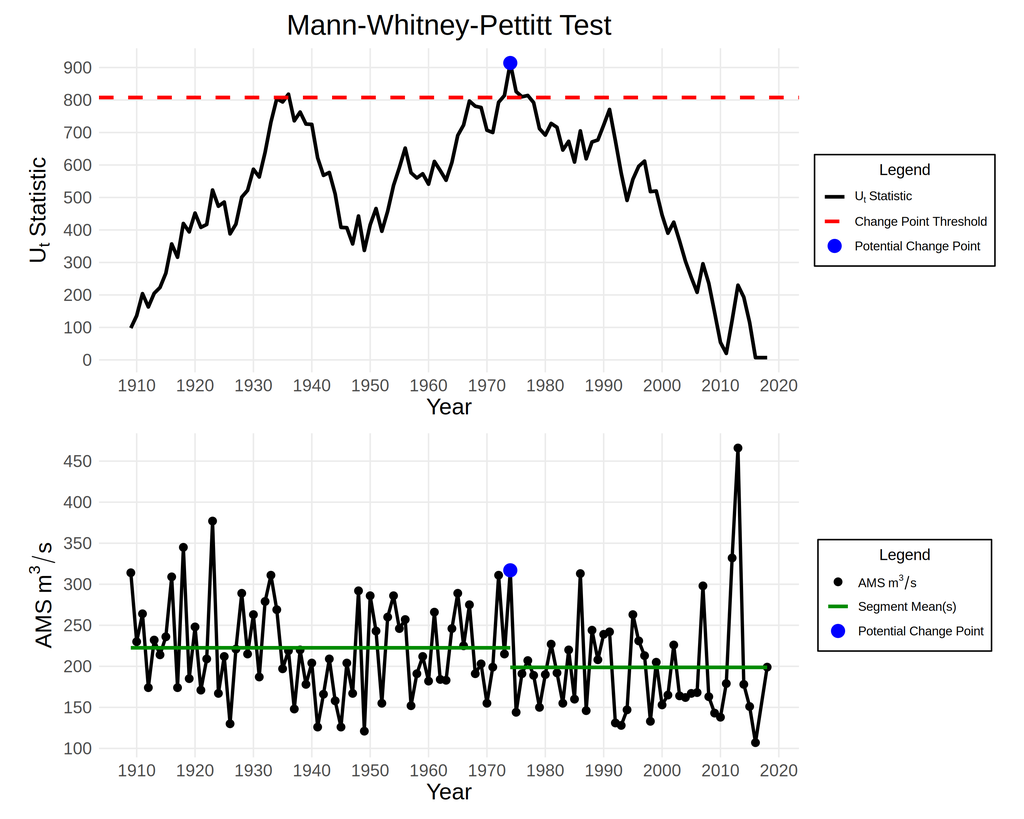

### Mann-Kendall-Sneyers Test

The **MKS Test** is used to identify the beginning of a trend in a time series:

- Null hypothesis: There are no change points in the time series.
- Alternative hypothesis: There are *one or more* change points in the time series.

#### Results

- The MKS test yielded a p-value of 1.
- At a significance level of 0.05, we fail to reject the null hypothesis.
- Therefore, there is NO evidence of change point(s).

Additional information:

- Number of crossings: 0
- Number of significant crossings: 0
- Significance threshold: 1.96

#### Figure

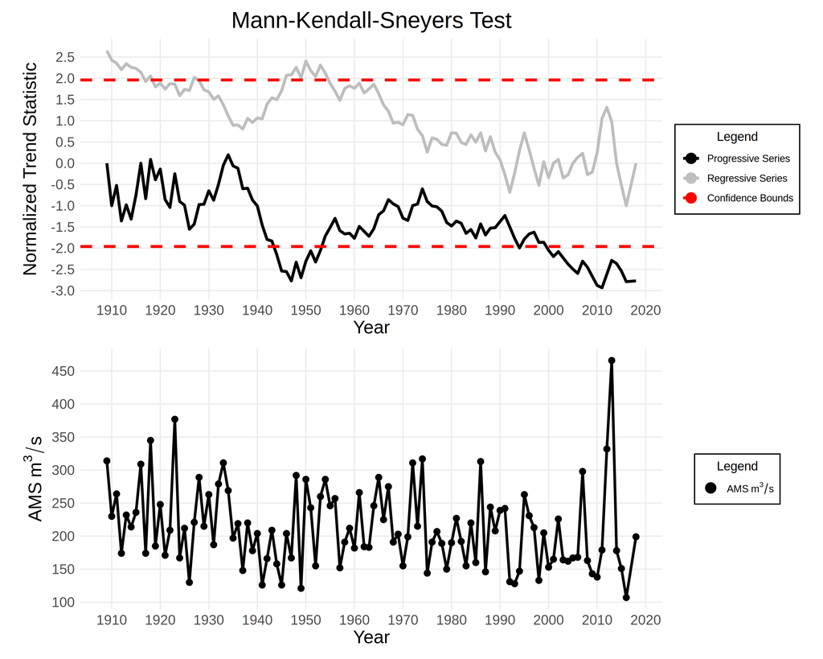

*Decision Point*: Change points ignored.

## TREND IDENTIFICATION IN AMS MEANS

### Mann-Kendall Test

The **MK Test** is used to assess whether there is a statistically significant monotonic trend in a time series. The test requires that when no trend is present, the data is independent and identically distributed.

- Null hypothesis: There is no monotonic trend.
- Alternative hypothesis: There is a monotonic upwards or downwards trend.

#### Results

- The MK test yielded a p-value of 0.007.
- At a significance level of 0.05, we reject the null hypothesis.
- Therefore, there is evidence of a significant monotonic trend.

Additional information:

- S-statistic: -1035
- S-statistic variance: 1.46e+05

*Branching Point*: Monotonic trend found. Testing for serial correlation.

### Spearman Test

The **Spearman Test** is used to identify autocorrelation in a time series $y_{t}$. A *significant lag* is a number $i$ such that the correlation between $y_{t}$ and $y_{t-i}$ is statistically significant. The *least insignificant lag* is the largest $i$ such that all $j < i$ are significant lags.

- Null hypothesis: The least insignificant lag is $0$.
- Alternative hypothesis: The least insignificant lag is greater than $0$.

#### Results

- The Spearman test found a least insignificant lag of 0.
- Therefore, there is NO evidence of serial correlation.

#### Figure

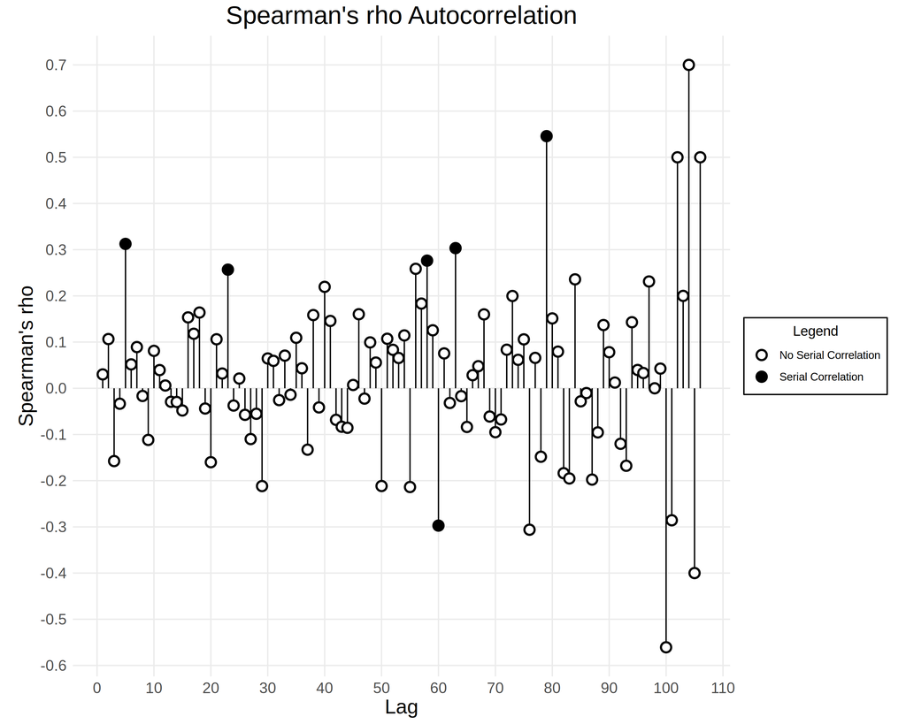

*Branching Point*: No serial correlation found. Estimating the monotonic trend.

### Sen’s Trend Estimator

**Dataset**: AMS mean.

**Sen’s Trend Estimator** is used to estimate the slope of a regression line. Unlike [Least Squares](https://en.wikipedia.org/wiki/Least_squares), Sen’s trend estimator uses a non-parametric approach which makes it robust to outliers.

After computing the regression line using Sen’s trend estimator, we use the **Runs Test** to determine whether the residuals from the regression are random. If the Runs test identifies a non-random pattern in the residuals, it is a strong indication that the non-stationarity in the data is non-linear.

- Null hypothesis: The residuals are distributed randomly.
- Alternative hypothesis: The residuals *are not* distributed randomly.

#### Results

- Estimated trend: y = -0.488x + 1159.68.
- The Runs test yielded a p-value of 0.439.
- At a significance level of 0.05, we fail to reject the null hypothesis.
- Therefore, there is evidence the residuals are random.

#### Figure

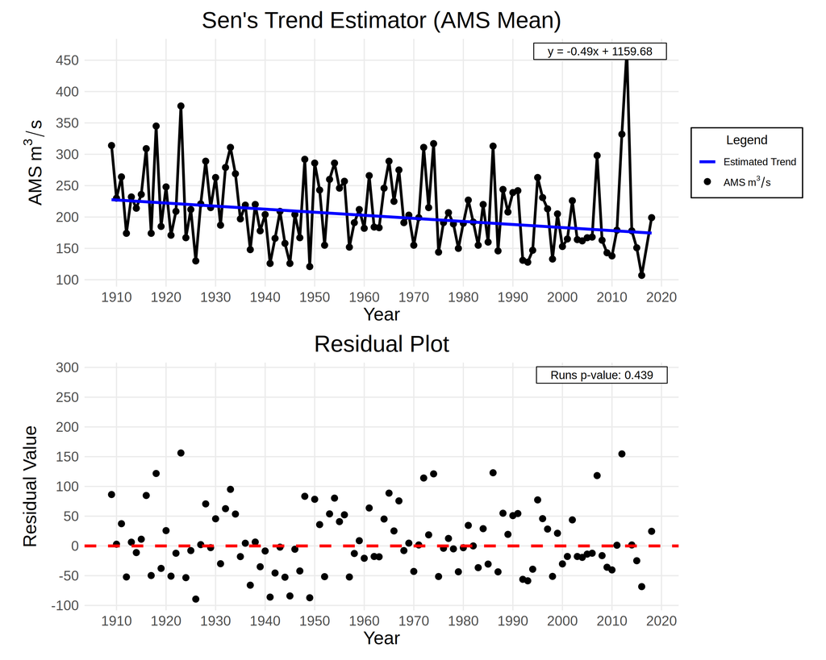

## TREND IDENTIFICATION IN AMS VARIANCE

### White Test

The **White Test** is used to detect changes in the variance of a time series.

- Null hypothesis: The variance of the time series is constant (homoskedasticity).
- Alternative hypothesis: The variance of the time series is time-dependent (heteroskedasticity).

#### Results

- The White test yielded a p-value of 0.087.
- At a significance level of 0.05, we fail to reject the null hypothesis.
- Therefore, there is evidence of homoskedasticity.

### Moving Window Mann-Kendall Test

The **MW-MK Test** is used to identify a statistically significant monotonic trend in the variances of an AMS time series.

- Null hypothesis: There is no significant trend in the variance of the AMS.
- Alternative hypothesis: There is a significant trend in the variance of the AMS.

#### Results

- The MK test yielded a p-value of 0.976.
- At a significance level of 0.05, we fail to reject the null hypothesis.
- Therefore, there is NO evidence of a significant monotonic trend.

Additional information:

- S-statistic: -2
- S-statistic variance: 1.1e+03

*Branching Point*: No time-dependence identified in the AMS variance. Generating a report.